# Ex. 05-2: Leveraging AnnotationHub to investigate epigenomics

## 1. Probe AnnotationHub for yeast ChIP-seq profiles

AnnotationHub provides access to a lot of pre-formated resources, all of that well embedded within the R environment. We hope to find more yeast ChIP-seq profiles referenced there.

> What type of information does AnnotationHub has in Yeast?

```r
library(AnnotationHub)
ah = AnnotationHub()
```

```
## snapshotDate(): 2020-10-27
```

```r
ah
```

```
## AnnotationHub with 54746 records
## # snapshotDate(): 2020-10-27
## # $dataprovider: Ensembl, BroadInstitute, UCSC, ftp://ftp.ncbi.nlm.nih.gov/g...
## # $species: Homo sapiens, Mus musculus, Drosophila melanogaster, Bos taurus,...
## # $rdataclass: GRanges, TwoBitFile, BigWigFile, Rle, EnsDb, OrgDb, ChainFile...
## # additional mcols(): taxonomyid, genome, description,
## #   coordinate_1_based, maintainer, rdatadateadded, preparerclass, tags,
## #   rdatapath, sourceurl, sourcetype
## # retrieve records with, e.g., 'object[["AH5012"]]'
##
##             title
##   AH5012  | Chromosome Band
##   AH5013  | STS Markers
##   AH5014  | FISH Clones
##   AH5015  | Recomb Rate
##   AH5016  | ENCODE Pilot
##   ...       ...
##   AH89078 | Zonotrichia_albicollis.Zonotrichia_albicollis-1.0.1.ncrna.2bit
##   AH89079 | Zosterops_lateralis_melanops.ASM128173v1.cdna.all.2bit
##   AH89080 | Zosterops_lateralis_melanops.ASM128173v1.dna_rm.toplevel.2bit
##   AH89081 | Zosterops_lateralis_melanops.ASM128173v1.dna_sm.toplevel.2bit
##   AH89082 | Zosterops_lateralis_melanops.ASM128173v1.ncrna.2bit
```

```r
head(sort(table(ah$species), decreasing = TRUE), 25)
```

```
##
##             Homo sapiens             Mus musculus  Drosophila melanogaster
##                    26459                     1615                      420
##               Bos taurus          Pan troglodytes        Rattus norvegicus
##                      316                      304                      303
##              Danio rerio            Gallus gallus    Monodelphis domestica
##                      295                      263                      240
##              Felis catus   Caenorhabditis elegans           Macaca mulatta
##                      233                      224                      222
##           Equus caballus         Canis familiaris       Callithrix jacchus
##                      218                      216                      210
##               Sus scrofa   Tetraodon nigroviridis      Anolis carolinensis
##                      198                      196                      193
## Ornithorhynchus anatinus   Gasterosteus aculeatus      Meleagris gallopavo
##                      185                      182                      181
##      Nomascus leucogenys          Oryzias latipes Saccharomyces cerevisiae
##                      181                      180                      176
##       Xenopus tropicalis
##                      176
```

```r
ah_yeast <- query(ah, "Saccharomyces cerevisiae")
ah_yeast
```

```
## AnnotationHub with 192 records
## # snapshotDate(): 2020-10-27
## # $dataprovider: Ensembl, UCSC, FungiDB, tRNAdb, ftp://ftp.ncbi.nlm.nih.gov/...
## # $species: Saccharomyces cerevisiae, saccharomyces cerevisiae, Saccharomyce...
## # $rdataclass: TwoBitFile, GRanges, EnsDb, ChainFile, TxDb, SQLiteFile, OrgD...
## # additional mcols(): taxonomyid, genome, description,
## #   coordinate_1_based, maintainer, rdatadateadded, preparerclass, tags,
## #   rdatapath, sourceurl, sourcetype
## # retrieve records with, e.g., 'object[["AH7039"]]'
##
##             title
##   AH7039  | WashU Clones
##   AH7040  | Other RefSeq
##   AH7041  | SGD Other
##   AH7042  | Human Proteins
##   AH7043  | Spliced ESTs
##   ...       ...
##   AH87694 | Saccharomyces_cerevisiae.R64-1-1.102.gtf
##   AH88835 | Saccharomyces_cerevisiae.R64-1-1.cdna.all.2bit
##   AH88836 | Saccharomyces_cerevisiae.R64-1-1.dna_rm.toplevel.2bit
##   AH88837 | Saccharomyces_cerevisiae.R64-1-1.dna_sm.toplevel.2bit
##   AH88838 | Saccharomyces_cerevisiae.R64-1-1.ncrna.2bit
```

```r
table(ah_yeast$sourcetype)
```

```
##
##          BED        Chain      ensembl        FASTA          GFF          GTF
##            1            6           15           85            3           51
##   Inparanoid NCBI/ensembl       TwoBit   UCSC track          XML
##            1            1            3           25            1
```

```r
query(ah_yeast, c("FASTA"))$title
```

```
##  [1] "Saccharomyces_cerevisiae.R64-1-1.cdna.all.2bit"
##  [2] "Saccharomyces_cerevisiae.R64-1-1.dna_rm.toplevel.2bit"
##  [3] "Saccharomyces_cerevisiae.R64-1-1.dna_sm.toplevel.2bit"
##  [4] "Saccharomyces_cerevisiae.R64-1-1.dna.toplevel.2bit"
##  [5] "Saccharomyces_cerevisiae.R64-1-1.ncrna.2bit"
##  [6] "Saccharomyces_cerevisiae.R64-1-1.cdna.all.2bit"
##  [7] "Saccharomyces_cerevisiae.R64-1-1.dna_rm.toplevel.2bit"
##  [8] "Saccharomyces_cerevisiae.R64-1-1.dna_sm.toplevel.2bit"
##  [9] "Saccharomyces_cerevisiae.R64-1-1.dna.toplevel.2bit"
## [10] "Saccharomyces_cerevisiae.R64-1-1.ncrna.2bit"
## [11] "Saccharomyces_cerevisiae.R64-1-1.cdna.all.2bit"
## [12] "Saccharomyces_cerevisiae.R64-1-1.dna_rm.toplevel.2bit"
## [13] "Saccharomyces_cerevisiae.R64-1-1.dna_sm.toplevel.2bit"
## [14] "Saccharomyces_cerevisiae.R64-1-1.dna.toplevel.2bit"
## [15] "Saccharomyces_cerevisiae.R64-1-1.ncrna.2bit"
```

[output cut: 71 more lines]

```r
query(ah_yeast, c("GTF"))$title
```

```
##  [1] "Saccharomyces_cerevisiae.EF4.69.gtf"
##  [2] "Saccharomyces_cerevisiae.EF4.70.gtf"
##  [3] "Saccharomyces_cerevisiae.EF4.71.gtf"
##  [4] "Saccharomyces_cerevisiae.EF4.72.gtf"
##  [5] "Saccharomyces_cerevisiae.EF4.73.gtf"
##  [6] "Saccharomyces_cerevisiae.EF4.74.gtf"
##  [7] "Saccharomyces_cerevisiae.R64-1-1.75.gtf"
##  [8] "Saccharomyces_cerevisiae.R64-1-1.78.gtf"
##  [9] "Saccharomyces_cerevisiae.R64-1-1.76.gtf"
## [10] "Saccharomyces_cerevisiae.R64-1-1.79.gtf"
## [11] "Saccharomyces_cerevisiae.R64-1-1.77.gtf"
## [12] "Saccharomyces_cerevisiae.R64-1-1.80.gtf"
## [13] "Saccharomyces_cerevisiae.R64-1-1.81.gtf"
## [14] "Saccharomyces_cerevisiae.R64-1-1.82.gtf"
## [15] "Saccharomyces_cerevisiae.R64-1-1.83.gtf"
```

[output cut: 36 more lines]

```r
query(ah_yeast, c("UCSC track"))$title
```

```
##  [1] "WashU Clones"    "Other RefSeq"    "SGD Other"       "Human Proteins"
##  [5] "Spliced ESTs"    "Regulatory Code" "Reg. Module"     "Simple Repeats"
##  [9] "Publications"    "SGD Genes"       "Ensembl Genes"   "S. cer. mRNAs"
## [13] "S. cer. ESTs"    "Reg. ChIP-chip"  "ORegAnno"        "Simple Repeats"
## [17] "GC Percent"      "SGD Genes"       "Ensembl Genes"   "S. cer. mRNAs"
## [21] "S. cer. ESTs"    "Reg. ChIP-chip"  "ORegAnno"        "Most Conserved"
## [25] "Simple Repeats"
```

> Can we recover Ensembl gene model from AnnotationHub? How does it compare to that obtain from a TxDb from UCSC (which is the one we used previously when checking overlap between ATAC peaks and genomic features)?

```r
query(ah, c("Saccharomyces cerevisiae", "R64-1-1", "gtf"))
```

```
## AnnotationHub with 45 records
## # snapshotDate(): 2020-10-27
## # $dataprovider: Ensembl
## # $species: Saccharomyces cerevisiae, saccharomyces cerevisiae
## # $rdataclass: GRanges
## # additional mcols(): taxonomyid, genome, description,
## #   coordinate_1_based, maintainer, rdatadateadded, preparerclass, tags,
## #   rdatapath, sourceurl, sourcetype
## # retrieve records with, e.g., 'object[["AH10712"]]'
##
##             title
##   AH10712 | Saccharomyces_cerevisiae.R64-1-1.75.gtf
##   AH28636 | Saccharomyces_cerevisiae.R64-1-1.78.gtf
##   AH28704 | Saccharomyces_cerevisiae.R64-1-1.76.gtf
##   AH28773 | Saccharomyces_cerevisiae.R64-1-1.79.gtf
##   AH28842 | Saccharomyces_cerevisiae.R64-1-1.77.gtf
##   ...       ...
##   AH80372 | Saccharomyces_cerevisiae.R64-1-1.100.gtf
##   AH83971 | Saccharomyces_cerevisiae.R64-1-1.101.abinitio.gtf
##   AH83972 | Saccharomyces_cerevisiae.R64-1-1.101.gtf
##   AH87693 | Saccharomyces_cerevisiae.R64-1-1.102.abinitio.gtf
##   AH87694 | Saccharomyces_cerevisiae.R64-1-1.102.gtf
```

```r
yeast_gtf <- ah[['AH79438']]
```

```
## downloading 1 resources
```

```
## retrieving 1 resource
```

```
## loading from cache
```

```
## Importing File into R ..
```

```
## require("rtracklayer")
```

```r
yeast_Ensembl_genes <- yeast_gtf[yeast_gtf$type == 'gene']
sort(yeast_Ensembl_genes)
```

```
## GRanges object with 7127 ranges and 15 metadata columns:
##          seqnames      ranges strand |   source     type     score     phase
##             <Rle>   <IRanges>  <Rle> | <factor> <factor> <numeric> <integer>
##      [1]        I     335-649      + |      sgd     gene        NA      <NA>
##      [2]        I     538-792      + |      sgd     gene        NA      <NA>
##      [3]        I   2480-2707      + |      sgd     gene        NA      <NA>
##      [4]        I 10091-10399      + |      sgd     gene        NA      <NA>
##      [5]        I 12046-12426      + |      sgd     gene        NA      <NA>
##      ...      ...         ...    ... .      ...      ...       ...       ...
##   [7123]     Mito 79213-80022      + |      sgd     gene        NA      <NA>
##   [7124]     Mito 85035-85112      + |      sgd     gene        NA      <NA>
##   [7125]     Mito 85295-85777      + |      sgd     gene        NA      <NA>
##   [7126]     Mito 85554-85709      + |      sgd     gene        NA      <NA>
##   [7127]     Mito 78089-78162      - |      sgd     gene        NA      <NA>
##              gene_id   gene_name gene_source   gene_biotype transcript_id
```

[output cut: 40 more lines]

```r
query(ah, c("Saccharomyces cerevisiae", "UCSC", "TxDb"))
```

```
## AnnotationHub with 2 records
## # snapshotDate(): 2020-10-27
## # $dataprovider: UCSC
## # $species: Saccharomyces cerevisiae
## # $rdataclass: TxDb
## # additional mcols(): taxonomyid, genome, description,
## #   coordinate_1_based, maintainer, rdatadateadded, preparerclass, tags,
## #   rdatapath, sourceurl, sourcetype
## # retrieve records with, e.g., 'object[["AH52271"]]'
##
##             title
##   AH52271 | TxDb.Scerevisiae.UCSC.sacCer2.sgdGene.sqlite
##   AH52272 | TxDb.Scerevisiae.UCSC.sacCer3.sgdGene.sqlite
```

```r
yeast_UCSC_genes <- GenomicFeatures::genes(ah[['AH52272']])
```

```
## loading from cache
```

```r
sort(yeast_UCSC_genes)
```

```
## GRanges object with 6534 ranges and 1 metadata column:
##             seqnames      ranges strand |     gene_id
##                <Rle>   <IRanges>  <Rle> | <character>
##     YAL069W     chrI     335-792      + |     YAL069W
##   YAL067W-A     chrI   2480-2707      + |   YAL067W-A
##     YAL066W     chrI 10091-10399      + |     YAL066W
##   YAL064W-B     chrI 12046-12426      + |   YAL064W-B
##     YAL064W     chrI 21566-21850      + |     YAL064W
##         ...      ...         ...    ... .         ...
##       Q0160     chrM 61022-61729      + |       Q0160
##       Q0182     chrM 65770-66174      + |       Q0182
##       Q0255     chrM 73758-75984      + |       Q0255
##       Q0275     chrM 79213-80022      + |       Q0275
##       Q0297     chrM 85554-85709      + |       Q0297
##   -------
##   seqinfo: 17 sequences (1 circular) from sacCer3 genome
```

> So is AnnotationHub really informative in our situation? In which organism/context could it be useful?

```r
ah_human_epigenome <- query(ah, c("Homo sapiens", "EpigenomeRoadMap"))
table(ah_human_epigenome$rdataclass)
```

```
##
## BigWigFile data.frame    GRanges
##       9932         15       8301
```

```r
head(query(ah_human_epigenome, 'BigWigFile')$title, 50)
```

```
##  [1] "E001-H3K4me1.fc.signal.bigwig"   "E001-H3K4me3.fc.signal.bigwig"
##  [3] "E001-H3K9ac.fc.signal.bigwig"    "E001-H3K9me3.fc.signal.bigwig"
##  [5] "E001-H3K27me3.fc.signal.bigwig"  "E001-H3K36me3.fc.signal.bigwig"
##  [7] "E002-H3K4me1.fc.signal.bigwig"   "E002-H3K4me3.fc.signal.bigwig"
##  [9] "E002-H3K9ac.fc.signal.bigwig"    "E002-H3K9me3.fc.signal.bigwig"
## [11] "E002-H3K27me3.fc.signal.bigwig"  "E002-H3K36me3.fc.signal.bigwig"
## [13] "E003-DNase.fc.signal.bigwig"     "E003-H2A.Z.fc.signal.bigwig"
## [15] "E003-H2AK5ac.fc.signal.bigwig"   "E003-H2BK5ac.fc.signal.bigwig"
## [17] "E003-H2BK12ac.fc.signal.bigwig"  "E003-H2BK15ac.fc.signal.bigwig"
## [19] "E003-H2BK20ac.fc.signal.bigwig"  "E003-H2BK120ac.fc.signal.bigwig"
## [21] "E003-H3K4ac.fc.signal.bigwig"    "E003-H3K4me1.fc.signal.bigwig"
## [23] "E003-H3K4me2.fc.signal.bigwig"   "E003-H3K4me3.fc.signal.bigwig"
## [25] "E003-H3K9ac.fc.signal.bigwig"    "E003-H3K9me3.fc.signal.bigwig"
## [27] "E003-H3K14ac.fc.signal.bigwig"   "E003-H3K18ac.fc.signal.bigwig"
## [29] "E003-H3K23ac.fc.signal.bigwig"   "E003-H3K23me2.fc.signal.bigwig"
## [31] "E003-H3K27ac.fc.signal.bigwig"   "E003-H3K27me3.fc.signal.bigwig"
## [33] "E003-H3K36me3.fc.signal.bigwig"  "E003-H3K56ac.fc.signal.bigwig"
## [35] "E003-H3K79me1.fc.signal.bigwig"  "E003-H3K79me2.fc.signal.bigwig"
## [37] "E003-H4K5ac.fc.signal.bigwig"    "E003-H4K8ac.fc.signal.bigwig"
## [39] "E003-H4K20me1.fc.signal.bigwig"  "E003-H4K91ac.fc.signal.bigwig"
## [41] "E004-DNase.fc.signal.bigwig"     "E004-H2AK5ac.fc.signal.bigwig"
## [43] "E004-H2BK5ac.fc.signal.bigwig"   "E004-H2BK15ac.fc.signal.bigwig"
## [45] "E004-H2BK120ac.fc.signal.bigwig" "E004-H3K4ac.fc.signal.bigwig"
## [47] "E004-H3K4me1.fc.signal.bigwig"   "E004-H3K4me2.fc.signal.bigwig"
## [49] "E004-H3K4me3.fc.signal.bigwig"   "E004-H3K9ac.fc.signal.bigwig"
```

## 2. Compare HMM-based chromatin state annotations in two human cell lines

```r
library(tidyverse)
epigenome_metadata <- query(ah_human_epigenome, 'data.frame')[[1]]
```

```
## loading from cache
```

```r
epigenome_metadata[1:10, 1:10]
```

```
## # A tibble: 10 x 10
##    EID   GROUP  COLOR  MNEMONIC  STD_NAME  EDACC_NAME  ANATOMY TYPE  AGE   SEX
##    <chr> <chr>  <chr>  <chr>     <chr>     <chr>       <chr>   <chr> <chr> <chr>
##  1 E001  ESC    #9249… ESC.I3    ES-I3 Ce… ES-I3_Cell… ESC     Prim… CL    Fema…
##  2 E002  ESC    #9249… ESC.WA7   ES-WA7 C… ES-WA7_Cel… ESC     Prim… CL    Fema…
##  3 E003  ESC    #9249… ESC.H1    H1 Cells  H1_Cell_Li… ESC     Prim… CL    Male
##  4 E004  ES-de… #4178… ESDR.H1.… H1 BMP4 … H1_BMP4_De… ESC_DE… ESCD… CL    Male
##  5 E005  ES-de… #4178… ESDR.H1.… H1 BMP4 … H1_BMP4_De… ESC_DE… ESCD… CL    Male
##  6 E006  ES-de… #4178… ESDR.H1.… H1 Deriv… H1_Derived… ESC_DE… ESCD… CL    Male
##  7 E007  ES-de… #4178… ESDR.H1.… H1 Deriv… H1_Derived… ESC_DE… ESCD… CL    Male
##  8 E008  ESC    #9249… ESC.H9    H9 Cells  H9_Cell_Li… ESC     Prim… CL    Fema…
##  9 E009  ES-de… #4178… ESDR.H9.… H9 Deriv… H9_Derived… ESC_DE… ESCD… CL    Fema…
## 10 E010  ES-de… #4178… ESDR.H9.… H9 Deriv… H9_Derived… ESC_DE… ESCD… CL    Fema…
```

```r
query(ah_human_epigenome, c("chromhmmSegmentations", "cell line"))
```

```
## AnnotationHub with 5 records
## # snapshotDate(): 2020-10-27
## # $dataprovider: BroadInstitute
## # $species: Homo sapiens
## # $rdataclass: GRanges
## # additional mcols(): taxonomyid, genome, description,
## #   coordinate_1_based, maintainer, rdatadateadded, preparerclass, tags,
## #   rdatapath, sourceurl, sourcetype
## # retrieve records with, e.g., 'object[["AH46872"]]'
##
##             title
##   AH46872 | E017_15_coreMarks_mnemonics.bed.gz
##   AH46967 | E114_15_coreMarks_mnemonics.bed.gz
##   AH46968 | E115_15_coreMarks_mnemonics.bed.gz
##   AH46970 | E117_15_coreMarks_mnemonics.bed.gz
##   AH46971 | E118_15_coreMarks_mnemonics.bed.gz
```

```r
H1_states <- query(ah_human_epigenome, c("chromhmmSegmentations", "ESC.H1"))[[1]]
```

```
## loading from cache
```

```r
NPC_states <- query(ah_human_epigenome, c("chromhmmSegmentations", "ESDR.H1.NEUR.PROG"))[[1]]
```

```
## loading from cache
```

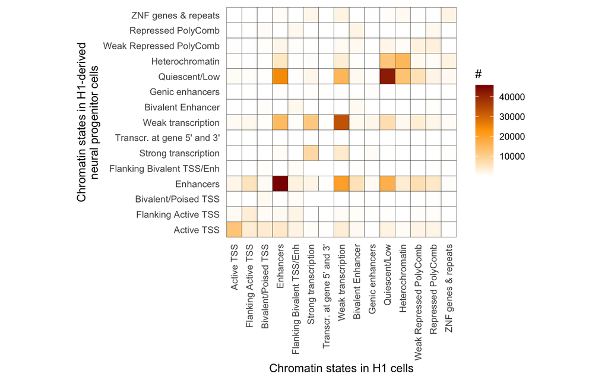

```r
H1_states <- resize(H1_states, 1, fix = 'center') # Resizing to make it easier to find overlap
NPC_states <- resize(NPC_states, 1, fix = 'center') # Resizing to make it easier to find overlap
H1_states$state_in_NPCs <- NPC_states[nearest(H1_states, NPC_states)]$name
states <- c(
    "Active TSS",
    "Flanking Active TSS",
    "Bivalent/Poised TSS",
    "Enhancers",
    "Flanking Bivalent TSS/Enh",
    "Strong transcription",
    "Transcr. at gene 5' and 3'",
    "Weak transcription",
    "Bivalent Enhancer",
    "Genic enhancers",
    "Quiescent/Low",
    "Heterochromatin",
    "Weak Repressed PolyComb",
    "Repressed PolyComb",
    "ZNF genes & repeats"
)
df <- data.frame(
    stateInH1 = factor(H1_states$name, levels = states),
    stateInNPCs = factor(H1_states$state_in_NPCs, levels = states)
)
p <- df %>%
    group_by(stateInH1, stateInNPCs) %>%
    summarize(count = n()) %>%
    ggplot(aes(x = stateInH1, y = stateInNPCs, fill = count)) +
    geom_tile(col = "black") +
    theme_bw() +
    scale_fill_gradientn(colours = c('white', 'orange', 'darkred')) +
    theme(
        axis.text.x = element_text(angle = 90, hjust = 1, vjust = 0.5),
        panel.border = element_blank(),
        panel.grid.major = element_blank(),
        panel.grid.minor = element_blank(),
        axis.ticks = element_blank()
    ) +
    labs(
        x = "Chromatin states in H1 cells",
        y = "Chromatin states in H1-derived\nneural progenitor cells",
        fill = '#'
    ) +
    coord_fixed()
p
```

> Which transitions can you detect?

```r
H1_states <- query(ah_human_epigenome, c("chromhmmSegmentations", "ESC.H1"))[[1]]
```

```
## loading from cache
```

```r
transitioning_loci <- H1_states[df$stateInH1 == 'Repressed PolyComb' & df$stateInNPCs == 'Enhancers']
```

> What are the closest genes?

```r
query(ah, c("Homo sapiens", "release-75"))
```

```
## AnnotationHub with 1 record
## # snapshotDate(): 2020-10-27
## # names(): AH10684
## # $dataprovider: Ensembl
## # $species: Homo sapiens
## # $rdataclass: GRanges
## # $rdatadateadded: 2014-04-27
## # $title: Homo_sapiens.GRCh37.75.gtf
## # $description: Gene Annotation for Homo sapiens
## # $taxonomyid: 9606
## # $genome: GRCh37
## # $sourcetype: GTF
## # $sourceurl: ftp://ftp.ensembl.org/pub/release-75/gtf/homo_sapiens/Homo_sap...
## # $sourcesize: 39344043
## # $tags: c("GTF", "ensembl", "Gene", "Transcript", "Annotation")
## # retrieve record with 'object[["AH10684"]]'
```

```r
human_gtf <- ah[['AH10684']]
```

```
## loading from cache
```

```r
human_Ensembl_genes <- human_gtf[human_gtf$type == 'gene' & human_gtf$gene_biotype == 'protein_coding']
human_Ensembl_TSSs <- resize(human_Ensembl_genes, 1, 'start')
human_Ensembl_TSSs
```

```
## GRanges object with 22810 ranges and 16 metadata columns:
##           seqnames    ranges strand |         source     type     score
##              <Rle> <IRanges>  <Rle> |       <factor> <factor> <numeric>
##       [1]        1     69091      + | protein_coding     gene        NA
##       [2]        1    139379      - | protein_coding     gene        NA
##       [3]        1    367640      + | protein_coding     gene        NA
##       [4]        1    622053      - | protein_coding     gene        NA
##       [5]        1    739137      - | protein_coding     gene        NA
##       ...      ...       ...    ... .            ...      ...       ...
##   [22806]       MT     10470      + | protein_coding     gene        NA
##   [22807]       MT     10760      + | protein_coding     gene        NA
##   [22808]       MT     12337      + | protein_coding     gene        NA
##   [22809]       MT     14673      - | protein_coding     gene        NA
##   [22810]       MT     14747      + | protein_coding     gene        NA
##               phase         gene_id   gene_name    gene_source   gene_biotype
```

[output cut: 40 more lines]

```r
#
seqlevelsStyle(transitioning_loci) <- "NCBI"
transitioning_loci <- keepStandardChromosomes(transitioning_loci, pruning.mode = 'coarse')
human_Ensembl_TSSs <- keepStandardChromosomes(human_Ensembl_TSSs, pruning.mode = 'coarse')
seqinfo(transitioning_loci) <- seqinfo(human_Ensembl_TSSs)
transitioning_loci$nearest_gene <- human_Ensembl_TSSs[nearest(transitioning_loci, human_Ensembl_TSSs)]$gene_name
transitioning_loci$distance_to_nearest_gene <- mcols(distanceToNearest(transitioning_loci, human_Ensembl_TSSs))$distance
```

> Are the associated genes involved in a specific process?

```r
genes <- unique(transitioning_loci$nearest_gene[transitioning_loci$distance_to_nearest_gene <= 500])
res <- gprofiler2::gost(genes, organism = 'hsapiens')
res$result %>% arrange(p_value)
```

```
## # A tibble: 16 x 14
##    query significant p_value term_size query_size intersection_si… precision
##    <chr> <lgl>         <dbl>     <int>      <int>            <int>     <dbl>
##  1 quer… TRUE        0.00304      8623        217              129    0.594
##  2 quer… TRUE        0.0105       2256        210               46    0.219
##  3 quer… TRUE        0.0115       2058        210               43    0.205
##  4 quer… TRUE        0.0149       1293        210               31    0.148
##  5 quer… TRUE        0.0149        873        210               24    0.114
##  6 quer… TRUE        0.0167       4283        217               75    0.346
##  7 quer… TRUE        0.0203         10        116                3    0.0259
##  8 quer… TRUE        0.0249         19        128                4    0.0312
##  9 quer… TRUE        0.0287       8666        217              126    0.581
## 10 quer… TRUE        0.0296       2353        210               46    0.219
## 11 quer… TRUE        0.0336          8        128                3    0.0234
## 12 quer… TRUE        0.0336          8        128                3    0.0234
## 13 quer… TRUE        0.0336          8        128                3    0.0234
## 14 quer… TRUE        0.0347       1485        217               35    0.161
## 15 quer… TRUE        0.0366         12        116                3    0.0259
## 16 quer… TRUE        0.0387        535        210               17    0.0810
## # … with 7 more variables: recall <dbl>, term_id <chr>, source <chr>,
## #   term_name <chr>, effective_domain_size <int>, source_order <int>,
## #   parents <list>
```

## Conclusions

> Can you conclude on the importance of having universal processing workflows to ensure the usefulness of a centralized database?